# IODS course project

Krishnan Narayanan

# About the project

This page is made as a part of my work in the Introduction to Open Data Science (IODS) course offered by UHelsinki in Spring 2017.

My github directory for the IODS project is [here](https://github.com/nkrish2014/IODS-project/)

# Week 2: Rstudio Exercise 2 - Regression and model validation

To develop the linear regression model we use the data, learn2014, is created using the R script in the Data wrangling exercise from the original data learning2014 available at http://www.helsinki.fi/~kvehkala/JYTmooc/JYTOPKYS3-data.txt.

The dataframe learn2014 has 166 observations and 7 variables.

In the first figure below, the graphical overview of the data variables, their distributions and relationships are given. The colours in the plot is based on gender. The correlation between variables shows that the variable “attitude” is highly correlated to “points”. The next two variables correlated to “points” are “stra” and “surf” considering the absolute value of the correlation.

So we develop a linear regression model, my_model3, with three variables with the formula “points ~ attitude + stra + surf”. The summary of the my_model3 gives the coefficients of the variables and the Residual standard error as 5.296. The p-value is 3.156e-08.

As the residual error is smaller for my_model 2 and it has a p-value smaller than that of my_model3, we choose my_model2.

The plots show the Residuals vs Fitted values, Normal QQ-plot and Residuals vs Leverage. These plots provide adequate justification for the assumptions taken for the regression model. The Residuals vs Fitted values are well clustered to suggest that the errors do not grow with the size of the data.

The normal QQ plot is linear suggesting that the normality assumption about the errors are justified. The residual vs leverage plot shows that the outliers do not impact the model.

```r
## Analysis  Linear Regression
# Loading the libraries for the plots

library(GGally)
library(ggplot2)

# loading the data from the file learning2014.txt created by
# the Data wrangling exercise

learn2014 <- read.table("learning2014.txt", sep="\t", header=TRUE)

# the dataframe learn2014 has 166 observations and 7 variables

str(learn2014)
```

```
## 'data.frame':    166 obs. of  7 variables:
##  $ gender  : Factor w/ 2 levels "F","M": 1 2 1 2 2 1 2 1 2 1 ...
##  $ age     : int  53 55 49 53 49 38 50 37 37 42 ...
##  $ attitude: num  3.7 3.1 2.5 3.5 3.7 3.8 3.5 2.9 3.8 2.1 ...
##  $ deep    : num  3.58 2.92 3.5 3.5 3.67 ...
##  $ stra    : num  3.38 2.75 3.62 3.12 3.62 ...
##  $ surf    : num  2.58 3.17 2.25 2.25 2.83 ...
##  $ points  : int  25 12 24 10 22 21 21 31 24 26 ...
```

```r
dim(learn2014)
```

```
## [1] 166   7
```

```r
head(learn2014)
```

```
##   gender age attitude     deep  stra     surf points
## 1      F  53      3.7 3.583333 3.375 2.583333     25
## 2      M  55      3.1 2.916667 2.750 3.166667     12
## 3      F  49      2.5 3.500000 3.625 2.250000     24
## 4      M  53      3.5 3.500000 3.125 2.250000     10
## 5      M  49      3.7 3.666667 3.625 2.833333     22
## 6      F  38      3.8 4.750000 3.625 2.416667     21
```

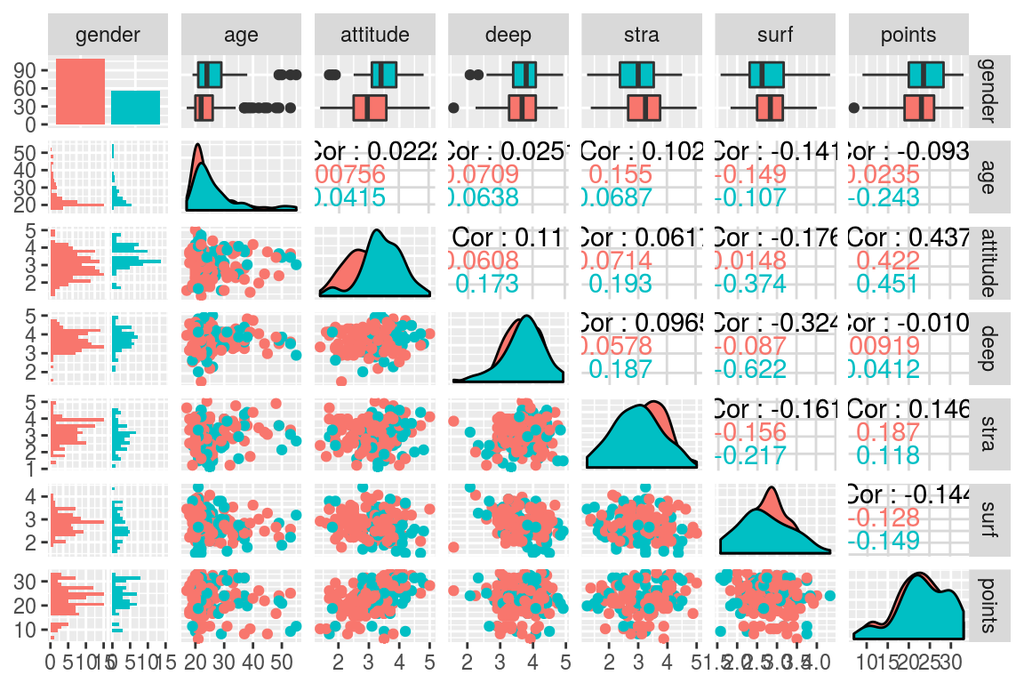

```r
# The graphical overview of the data variables, their distributions and relationships.
# the colours in the plot is based on gender

p <- ggpairs(learn2014, mapping = aes(col = gender), lower = list(combo = wrap("facethist", bins = 20)))

# show  the plot of correlation of variables
p
```

```r
# model fitting with three variables.
# The three variables which have highest absolute correlation values with
# points are chosen from the plot p. These variables are attitude, stra and surf.
# The summary of my_model3 gives

# Residual standard error: 5.296 on 162 degrees of freedom
# Multiple R-squared:  0.2074,  Adjusted R-squared:  0.1927
# F-statistic: 14.13 on 3 and 162 DF,  p-value: 3.156e-08
# From the summary the t value for surf is quite small compared to
# the t values of the other two variables

my_model3 <- lm(points ~ attitude + stra + surf, data = learn2014)
summary(my_model3)
```

```
##
## Call:
## lm(formula = points ~ attitude + stra + surf, data = learn2014)
##
## Residuals:
##      Min       1Q   Median       3Q      Max
## -17.1550  -3.4346   0.5156   3.6401  10.8952
##
## Coefficients:
##             Estimate Std. Error t value Pr(>|t|)
## (Intercept)  11.0171     3.6837   2.991  0.00322 **
## attitude      3.3952     0.5741   5.913 1.93e-08 ***
## stra          0.8531     0.5416   1.575  0.11716
## surf         -0.5861     0.8014  -0.731  0.46563
## ---
## Signif. codes:  0 '***' 0.001 '**' 0.01 '*' 0.05 '.' 0.1 ' ' 1
##
## Residual standard error: 5.296 on 162 degrees of freedom
## Multiple R-squared:  0.2074, Adjusted R-squared:  0.1927
## F-statistic: 14.13 on 3 and 162 DF,  p-value: 3.156e-08
```

```r
# model fitting with two variables: attitude and stra as stra has a higher correlation
# to points compared to surf
# The summary of the model gives
# Residual standard error: 5.289 on 163 degrees of freedom
# Multiple R-squared:  0.2048,  Adjusted R-squared:  0.1951
# F-statistic: 20.99 on 2 and 163 DF,  p-value: 7.734e-09

my_model2 <- lm(points ~ attitude + stra, data = learn2014)
summary(my_model2)
```

```
##
## Call:
## lm(formula = points ~ attitude + stra, data = learn2014)
##
## Residuals:
##      Min       1Q   Median       3Q      Max
## -17.6436  -3.3113   0.5575   3.7928  10.9295
##
## Coefficients:
##             Estimate Std. Error t value Pr(>|t|)
## (Intercept)   8.9729     2.3959   3.745  0.00025 ***
## attitude      3.4658     0.5652   6.132 6.31e-09 ***
## stra          0.9137     0.5345   1.709  0.08927 .
## ---
## Signif. codes:  0 '***' 0.001 '**' 0.01 '*' 0.05 '.' 0.1 ' ' 1
##
## Residual standard error: 5.289 on 163 degrees of freedom
## Multiple R-squared:  0.2048, Adjusted R-squared:  0.1951
## F-statistic: 20.99 on 2 and 163 DF,  p-value: 7.734e-09
```

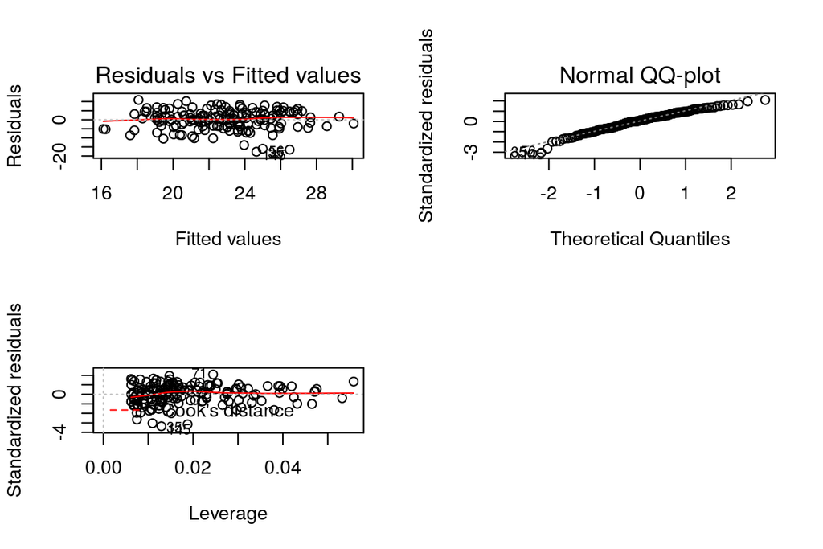

```r
# We plot the graphs  Residuals vs Fitted values, Normal QQ-plot and Residuals vs Leverage.
par(mfrow = c(2,2))
plot(my_model2, which = c(1,2,5), caption = list("Residuals vs Fitted values", "Normal QQ-plot", "Residuals vs Leverage"))
```

## Logistic regression

In this chapter we analyse the datasets on student alcohol consumption in secondary schools in Portugal using Logistic regression.

The data is obtained from two questionnaires related to student alcohol consumption and is available at UCI Machine Learning Repository, [Student Alcohol consumption data page](https://archive.ics.uci.edu/ml/datasets/STUDENT+ALCOHOL+CONSUMPTION). The data consists of answers to two questionaires, one from math class and another from protugese language class related to student alcohol consumption in secondary school students in Portugal

The purpose of our analysis is to study the relationships between high/low alcohol consumption and some of the influencing variables in the data.

## The alc dataset

Using the program create_alc.R we joined the above two datsets to a new datset alc. The alc data set has two new columns alc_use, which is the average of weekday and weekend alcohol consumption and another column high_use which is true if alc_use > 2. This dataset is also available [here](http://s3.amazonaws.com/assets.datacamp.com/production/course_2218/datasets/alc.txt)

### The variables (attributes) of alc dataframe

1. school - student’s school (binary: ‘GP’ - Gabriel Pereira or ‘MS’ - Mousinho da Silveira)
2. sex - student’s sex (binary: ‘F’ - female or ‘M’ - male)
3. age - student’s age (numeric: from 15 to 22)
4. address - student’s home address type (binary: ‘U’ - urban or ‘R’ - rural)
5. famsize - family size (binary: ‘LE3’ - less or equal to 3 or ‘GT3’ - greater than 3)
6. Pstatus - parent’s cohabitation status (binary: ‘T’ - living together or ‘A’ - apart)
7. Medu - mother’s education (numeric: 0 - none, 1 - primary education (4th grade), 2 5th to 9th grade, 3 secondary education or 4 higher education)
8. Fedu - father’s education (numeric: 0 - none, 1 - primary education (4th grade), 2 5th to 9th grade, 3 secondary education or 4 higher education)
9. Mjob - mother’s job (nominal: ‘teacher’, ‘health’ care related, civil ‘services’ (e.g. administrative or police), ‘at_home’ or ‘other’)
10. Fjob - father’s job (nominal: ‘teacher’, ‘health’ care related, civil ‘services’ (e.g. administrative or police), ‘at_home’ or ‘other’)
11. reason - reason to choose this school (nominal: close to ‘home’, school ‘reputation’, ‘course’ preference or ‘other’)
12. guardian - student’s guardian (nominal: ‘mother’, ‘father’ or ‘other’)
13. traveltime - home to school travel time (numeric: 1 - <15 min., 2 - 15 to 30 min., 3 - 30 min. to 1 hour, or 4 - >1 hour)
14. studytime - weekly study time (numeric: 1 - <2 hours, 2 - 2 to 5 hours, 3 - 5 to 10 hours, or 4 - >10 hours)
15. failures - number of past class failures (numeric: n if 1<=n<3, else 4)
16. schoolsup - extra educational support (binary: yes or no)
17. famsup - family educational support (binary: yes or no)
18. paid - extra paid classes within the course subject (Math or Portuguese) (binary: yes or no)
19. activities - extra-curricular activities (binary: yes or no)
20. nursery - attended nursery school (binary: yes or no)
21. higher - wants to take higher education (binary: yes or no)
22. internet - Internet access at home (binary: yes or no)
23. romantic - with a romantic relationship (binary: yes or no)
24. famrel - quality of family relationships (numeric: from 1 - very bad to 5 - excellent)
25. freetime - free time after school (numeric: from 1 - very low to 5 - very high)
26. goout - going out with friends (numeric: from 1 - very low to 5 - very high)
27. Dalc - workday alcohol consumption (numeric: from 1 - very low to 5 - very high)
28. Walc - weekend alcohol consumption (numeric: from 1 - very low to 5 - very high)
29. health - current health status (numeric: from 1 - very bad to 5 - very good)
30. absences - number of school absences (numeric: from 0 to 93)
31. G1 - first period grade (numeric: from 0 to 20)
32. G2 - second period grade (numeric: from 0 to 20)
33. G3 - final grade (numeric: from 0 to 20, output target)
34. alc_use - average of weekday and weekend alcohol consumption
35. high_use is True if alc_use > 2

### Answer to question 2

### Reading the alc data set from amazonaws to alc dataframe

```r
alc <- read.table("http://s3.amazonaws.com/assets.datacamp.com/production/course_2218/datasets/alc.txt", sep = ",", header=TRUE)
dim(alc)
```

```
## [1] 382  35
```

```r
summary(alc)
```

```
##  school   sex          age        address famsize   Pstatus
##  GP:342   F:198   Min.   :15.00   R: 81   GT3:278   A: 38
##  MS: 40   M:184   1st Qu.:16.00   U:301   LE3:104   T:344
##                   Median :17.00
##                   Mean   :16.59
##                   3rd Qu.:17.00
##                   Max.   :22.00
##       Medu            Fedu             Mjob           Fjob
##  Min.   :0.000   Min.   :0.000   at_home : 53   at_home : 16
##  1st Qu.:2.000   1st Qu.:2.000   health  : 33   health  : 17
##  Median :3.000   Median :3.000   other   :138   other   :211
##  Mean   :2.806   Mean   :2.565   services: 96   services:107
##  3rd Qu.:4.000   3rd Qu.:4.000   teacher : 62   teacher : 31
##  Max.   :4.000   Max.   :4.000
##         reason    nursery   internet    guardian     traveltime
##  course    :140   no : 72   no : 58   father: 91   Min.   :1.000
##  home      :110   yes:310   yes:324   mother:275   1st Qu.:1.000
##  other     : 34                       other : 16   Median :1.000
##  reputation: 98                                    Mean   :1.442
##                                                    3rd Qu.:2.000
##                                                    Max.   :4.000
##    studytime        failures      schoolsup famsup     paid     activities
##  Min.   :1.000   Min.   :0.0000   no :331   no :144   no :205   no :181
##  1st Qu.:1.000   1st Qu.:0.0000   yes: 51   yes:238   yes:177   yes:201
##  Median :2.000   Median :0.0000
##  Mean   :2.034   Mean   :0.2906
##  3rd Qu.:2.000   3rd Qu.:0.0000
##  Max.   :4.000   Max.   :3.0000
##  higher    romantic      famrel        freetime         goout
##  no : 18   no :261   Min.   :1.00   Min.   :1.000   Min.   :1.000
##  yes:364   yes:121   1st Qu.:4.00   1st Qu.:3.000   1st Qu.:2.000
##                      Median :4.00   Median :3.000   Median :3.000
##                      Mean   :3.94   Mean   :3.223   Mean   :3.113
##                      3rd Qu.:5.00   3rd Qu.:4.000   3rd Qu.:4.000
##                      Max.   :5.00   Max.   :5.000   Max.   :5.000
##       Dalc            Walc          health         absences
##  Min.   :1.000   Min.   :1.00   Min.   :1.000   Min.   : 0.000
##  1st Qu.:1.000   1st Qu.:1.00   1st Qu.:3.000   1st Qu.: 0.000
##  Median :1.000   Median :2.00   Median :4.000   Median : 3.000
##  Mean   :1.474   Mean   :2.28   Mean   :3.579   Mean   : 5.319
##  3rd Qu.:2.000   3rd Qu.:3.00   3rd Qu.:5.000   3rd Qu.: 8.000
##  Max.   :5.000   Max.   :5.00   Max.   :5.000   Max.   :75.000
##        G1              G2              G3           alc_use
##  Min.   : 3.00   Min.   : 0.00   Min.   : 0.00   Min.   :1.000
##  1st Qu.: 8.00   1st Qu.: 8.25   1st Qu.: 8.00   1st Qu.:1.000
##  Median :10.50   Median :11.00   Median :11.00   Median :1.500
##  Mean   :10.86   Mean   :10.71   Mean   :10.39   Mean   :1.877
##  3rd Qu.:13.00   3rd Qu.:13.00   3rd Qu.:14.00   3rd Qu.:2.500
##  Max.   :19.00   Max.   :19.00   Max.   :20.00   Max.   :5.000
##   high_use
##  Mode :logical
##  FALSE:270
##  TRUE :112
##  NA's :0
##
##
```

### Answer to question 2

We can see the distribution of the variables by drawing a bar plot using ggplot.

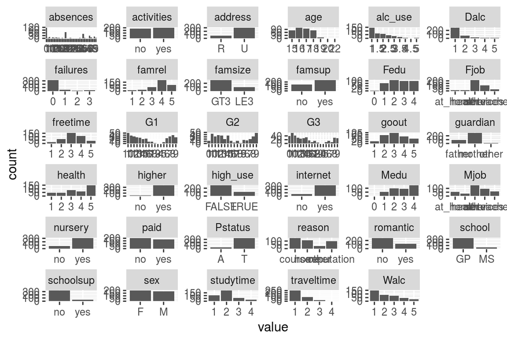

```r
library(tidyr); library(dplyr); library(ggplot2); library(GGally)
gather(alc) %>% ggplot(aes(value)) + facet_wrap("key", scales = "free") + geom_bar()
```

### Answer to question 3 Based on the analysis we performed on the data in the datacamp exercise on this topic, we could select the three attributes sex, absence, failures. As the fourth attribute I choose final grade G3.

### Answer to question 4

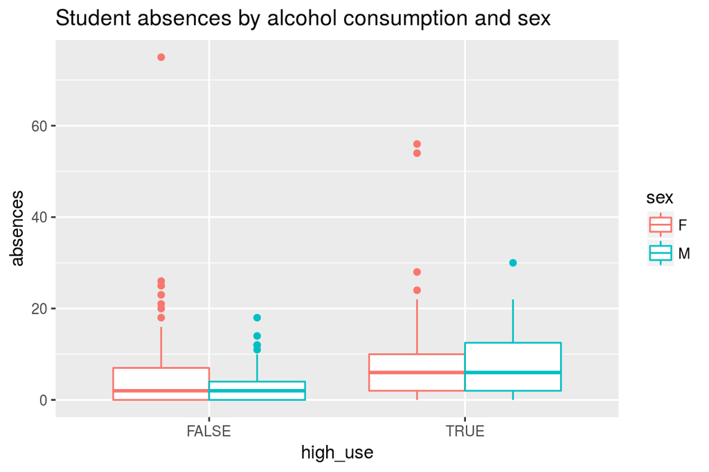

```r
# initialise a plot of high_use and absence

g2 <- ggplot(alc, aes(x = high_use, y = absences, col = sex))
# define the plot as a boxplot and draw it
g2 + geom_boxplot() + ylab("absences") + ggtitle("Student absences by alcohol consumption and sex" )
```

From the graph of Student absences by alcohol consumption and sex, “absences” have a high 75-percentile value “high_use” group. So we select this variable.

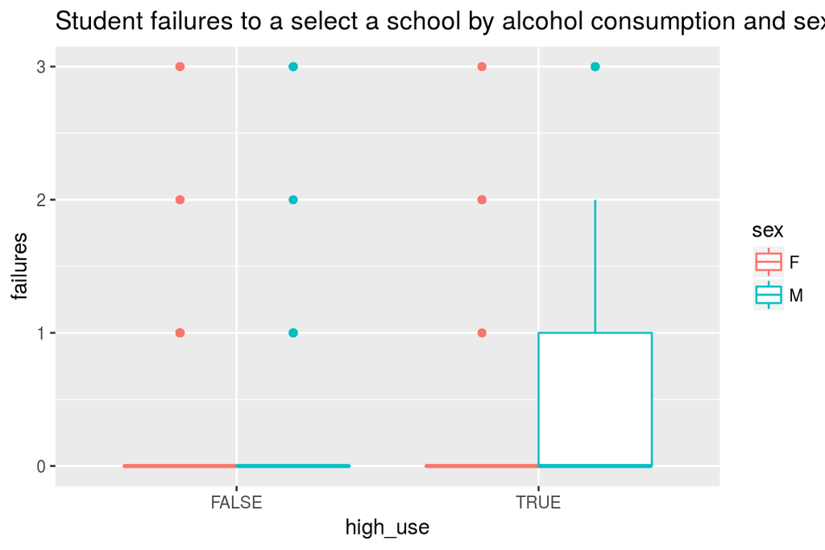

```r
# initialise a plot of high_use and reason
g2 <- ggplot(alc, aes(x = high_use, y = failures, col = sex))
# define the plot as a boxplot and draw it
g2 + geom_boxplot() + ylab("failures") + ggtitle("Student failures to a select a school by alcohol consumption and sex" )
```

The above graph shows that the student failures are affected by alcohol consumption

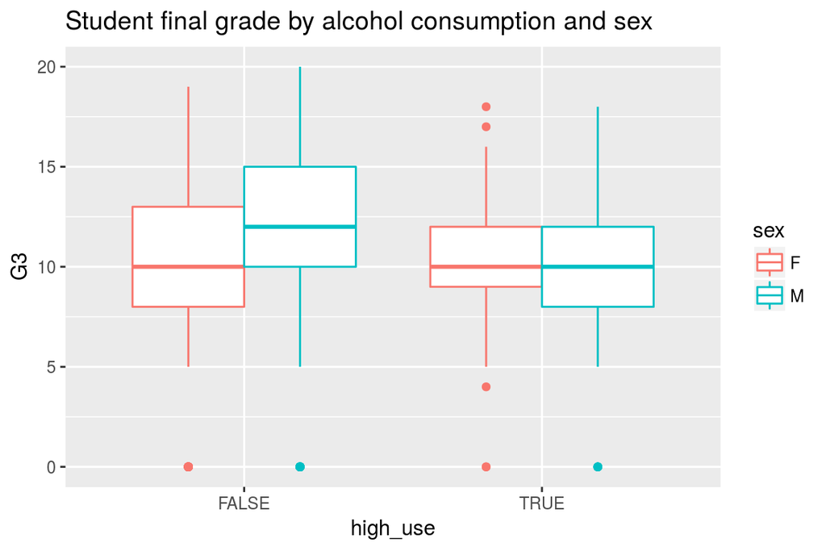

```r
# initialise a plot of high_use and G3
g2 <- ggplot(alc, aes(x = high_use, y = G3, col = sex))
# define the plot as a boxplot and draw it
g2 + geom_boxplot() + ylab("G3") + ggtitle("Student final grade by alcohol consumption and sex" )
```

So based on the analysis described here, we have selected the variables sex, absences, failures and the final grade G3 as the explanatory variables for the prediction on high_use ### Answer to question 5 Logistic regression model

```r
m <- glm(high_use ~ absences + sex + failures + G3, data = alc, family = "binomial")

# compute odds ratios (OR)
OR <- coef(m) %>% exp

# compute confidence intervals (CI)
CI <- confint(m) %>% exp

# print out the odds ratios with their confidence intervals
cbind(OR, CI)
```

```
##                    OR      2.5 %    97.5 %
## (Intercept) 0.1543884 0.07228561 0.3118277
## absences    1.0760416 1.04094428 1.1169817
## sexM        2.7139664 1.68292966 4.4410514
## failures    1.4688181 1.06216640 2.0400805
## G3          0.9917434 0.93812627 1.0497828
```

```r
cbind
```

[output not shown]

```r
summary(m)
```

```
##
## Call:
## glm(formula = high_use ~ absences + sex + failures + G3, family = "binomial",
##     data = alc)
##
## Deviance Residuals:
##     Min       1Q   Median       3Q      Max
## -2.6766  -0.8366  -0.5906   1.0313   2.0664
##
## Coefficients:
##              Estimate Std. Error z value Pr(>|z|)
## (Intercept) -1.868283   0.371774  -5.025 5.03e-07 ***
## absences     0.073289   0.018050   4.060 4.90e-05 ***
## sexM         0.998411   0.247017   4.042 5.30e-05 ***
## failures     0.384458   0.165357   2.325   0.0201 *
## G3          -0.008291   0.028599  -0.290   0.7719
## ---
## Signif. codes:  0 '***' 0.001 '**' 0.01 '*' 0.05 '.' 0.1 ' ' 1
##
## (Dispersion parameter for binomial family taken to be 1)
##
##     Null deviance: 462.21  on 381  degrees of freedom
## Residual deviance: 418.56  on 377  degrees of freedom
## AIC: 428.56
##
## Number of Fisher Scoring iterations: 4
```

Here we have a categorical variable sex whhich has two levels male and female. To check whether the whole variable Sex improves the model fit, we fit one model with (m1) with variable sex and one without the variable sex (m2) and conduct a likelihood ratio test. This tests the hypothesis that all coefficients of sex are zero:

```r
m1 <- glm(high_use ~ absences + sex + failures + G3, data = alc, family = "binomial")
m2 <- glm(high_use ~ absences + failures + G3, data = alc, family = "binomial")

anova(m1, m2, test="LRT")
```

```
## Analysis of Deviance Table
##
## Model 1: high_use ~ absences + sex + failures + G3
## Model 2: high_use ~ absences + failures + G3
##   Resid. Df Resid. Dev Df Deviance  Pr(>Chi)
## 1       377     418.56
## 2       378     435.66 -1  -17.105 3.538e-05 ***
## ---
## Signif. codes:  0 '***' 0.001 '**' 0.01 '*' 0.05 '.' 0.1 ' ' 1
```

The likelihood ratio test is highly significant and we would conclude that the variable sex should remain in the model.

### Answer to question 6

Logistic regression enables to predict binary outcomes. We use the data alc to make the predictions for high:use.

```r
m <- glm(high_use ~ absences + sex + failures + G3, data = alc, family = "binomial")
# predict() the probability of high_use
probabilities <- predict(m, type = "response")

# add the predicted probabilities to 'alc'
alc <- mutate(alc, probability = probabilities)

# use the probabilities to make a prediction of high_use
alc <- mutate(alc, prediction = probability > 0.5)
# tabulate the target variable versus the predictions
table(high_use = alc$high_use, prediction = alc$prediction)
```

```
##         prediction
## high_use FALSE TRUE
##    FALSE   258   12
##    TRUE     86   26
```

We see from the results that the high_use prediction is fairly accurate when the high_use has the state FALSE, and the prediction is rather poor when high_use has the state TRUE.